# Exercise 12, Question 1

Lindsay Serene and Michelle Wang

11/21/2017

### **Aim 1: Describe the data of chickwts.txt**

Set working directory:

```r
setwd("~/Desktop/")
```

Load the necessary libraries:

```r
library(ggplot2)
library(deSolve)
```

Open chickwts.txt and assign it a variable name.

```r
D = read.table(file = "chickwts.txt", header = TRUE, sep = "," , stringsAsFactors = FALSE)
```

The data is presented in two columns: **feed** and **weight**. **Feed** is additionally subdivided into 6 categories based on **feed** type.

### **Aim 2: Plot the data.**

As a dot plot:

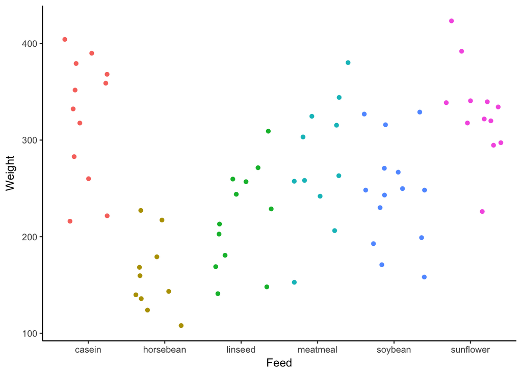

```r
ggplot(data = D, aes(x = feed, y = weight))+theme_classic()+coord_cartesian()+geom_jitter(aes(color=as.factor(feed)))+theme(legend.position="none")+xlab("Feed")+ylab("Weight")
```

As a bar graph:

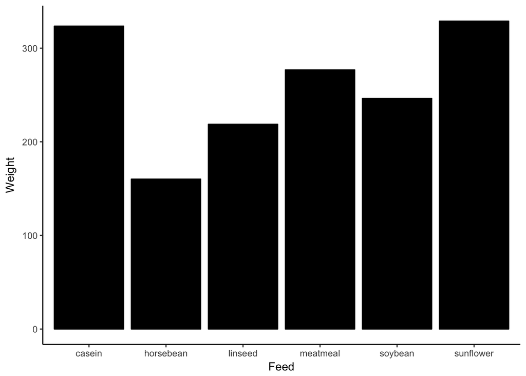

```r
ggplot(data = D)+geom_bar(aes(x =as.factor(feed), y = weight), stat = "summary",fun.y = "mean", fill = "black", color = "black") +
  theme_classic() +xlab("Feed") +ylab("Weight")
```

### **Aim 3: State a hypothesis (H_A) and null hypothesis (H_0) based on the data.**

- *H_A=there is a differnece in **weight** between chicks **fed** soybean as compared to those **fed** sunflower seeds.*
- *H_0=there is NO difference in **weight** between chicks **fed** soybean as compared to those **fed** sunflower seeds.*

### **Aim 4: Test the null hypothesis using a likelihood ratio test.**

Subset the **feed** type “soybean” into a variable called Soybean:

```r
Soybean <- subset(D, feed == "soybean", c(1,2))
```

Subset the **feed** type “sunflower” into a variable called Sunflower.

```r
Sunflower <- subset(D, feed == "sunflower", c(1,2))
```

Combine subsets Soybean and Sunflower into one dataframe called df.feed:

```r
df.feed <- rbind.data.frame(Soybean[c("weight", "feed")], Sunflower[c("weight", "feed")])
```

Define a log likelihood function:

```r
LL = function(data.in, mu.in, sd.in){
  sum(dnorm(data.in, mu.in, sd.in, log = T))
}
```

Obtain MLEs for the two hypothesized models:

```r
H_0 = optim(
  par=c(340,10),
  function(par){
    -LL(df.feed$weight,par[1],par[2])})
H_A = optim(
  par=c(340,350,10),
  function(par){
    -LL(subset(df.feed,feed=='soybean')$weight,par[1],par[3]) +
      -LL(subset(df.feed,feed=='sunflower')$weight,par[2],par[3])})
```

Perform a likelihood ratio test to determine whether we can reject the null hypothesis (H_0):

```r
dchisq(-2 * (-H_0$value - -H_A$value), 1)
```

```
## [1] 0.0001242373
```